# Tutorial 1

[Aurel Mélard](https://sites.google.com/view/aurel-melard)

aurel.melard@polytechnique.edu

CREST - Institut Polytechnique de Paris - IPP

February 10, 2026

## Roadmap

For this first tutorial, we are going to

1. Download R and Rstudio
2. Discover the software
3. Make our first data visualisation
4. Learn how to export them and input them in a `.tex` file.

## What is R? Set-up and launch

R is a free and open-source software used in many contexts: data cleaning, data visualisation, econometrics, machine and deep learning, among others.

It is supported by a lively and active user community.

R is an **object-based** language, meaning that we are going to manipulate objects through a series of commands.

R can be used directly from a command terminal, but also and preferably through RStudio, an IDE. An IDE (*integrated development environment*) is an interface that eases the use of a software. The most popular one is `RStudio`. To use it, we need to:

1. Download R
2. Then, download RStudio

> You can download both from here https://posit.co/download/rstudio-desktop/.

## General best practices

Before jumping to coding *per se*, let’s recall some best practices when performing computer-based tasks.

### Folder organization

Computers are organized around folder. We are going to work in a working directory (`wd`), but we need to identify it. My folder tree looks like it:

```
/Users/aurelmelard/Dropbox
├── Admin
├── IPP
│   ├── AA
│   ├── Echange
│   ├── EvaluationCEE
│   ├── MaPrimeRenov
│   └── Pension_RG
├── Perso
├── cours
│   ├── PublicEcon_cours
│   └── Topics
│       ├── 2026_eco1s002
│       │   ├── README_files
│       │   ├── data
│       │   ├── docs
│       │   ├── img
│       │   ├── output
│       ├── extra_material
│       └── tuto_solutions
└── projet_ZFE
```

### Naming convention

A typical tip is to choose simple and short titles for the files and the scripts. For instance, this file for this class is named `tutorial1.qmd`. Your code can be named `tutorial1.R`. It should be self-explanatory.

### When writing code

- **Always** comment your code, make it readable for your future self but also for others. You/they may use your code in a week, a month, a year, and should be able to directly understand it.
- When creating/saving objects (data, functions, parameters) give them simple but understandable names.
- For instance, if you create a data frame containing wages for individuals aged between 25 and 30, you may call it `wage_25_30`, not `w2530` (too short), nor `wage_individuals_aged_25_30` (too long).
- Moreover, especially for large project, you want to have different scripts. Always keep scripts short and with clear names. For instance `1_clean_data.R`, `2_import_wages.R`, `3_merge_datasets.R`, and `4_data_analysis.R`.

## First step in R/Rstudio

### Opening a script (and useful terms)

- We are going to create our first `script` (the extension is `.R`).
  - First, open RStudio and open a new script.
  - You should have an empty page. First write some some description of what the code does.
  - This script will then contain the commands you want to run.
  - Save it as `tutorial1.R` in the appropriate folder.

**Tip**

Along the way, you can use `#` to comment code and `----` to decompose your code into parts with titles.

- In this script, we are going to manipulate `objects` using `functions`.
- Objects can be of different `classes`: matrix, vector, character, numeric, data.frame, etc.
- Some functions are built in `R` but some are not. In this case, we need to load their related `packages`.

## First step in R/Rstudio

### Script

```r
#######################################################
# Tutorial 1:
# This script opens the iris dataset and
# performs data visualization taks on it
#
# Author: Aurel Mélard (aurel.melard@polytechnique.edu)
# Date: 11/02/2026
######################################################

## 1. Set input and output paths ----
output_path <- "/Users/aurelmelard/Dropbox/cours/Topics/2026_eco1s002/output"
```

Notice that we created our first object, named `output_path` using the assignment operator `<-` (or `=`, which is equivalent).

**Tip**

## First step in R/Rstudio

### Our first data manipulation

We can load a famous built-in data set, the `iris` dataset, into an object called `data`.

```r
data = iris # Attribute to data the data set iris
class(data) # Check its class
```

```
[1] "data.frame"
```

```r
head(data) # Preview the first lines of data
```

```
  Sepal.Length Sepal.Width Petal.Length Petal.Width Species
1          5.1         3.5          1.4         0.2  setosa
2          4.9         3.0          1.4         0.2  setosa
3          4.7         3.2          1.3         0.2  setosa
4          4.6         3.1          1.5         0.2  setosa
5          5.0         3.6          1.4         0.2  setosa
6          5.4         3.9          1.7         0.4  setosa
```

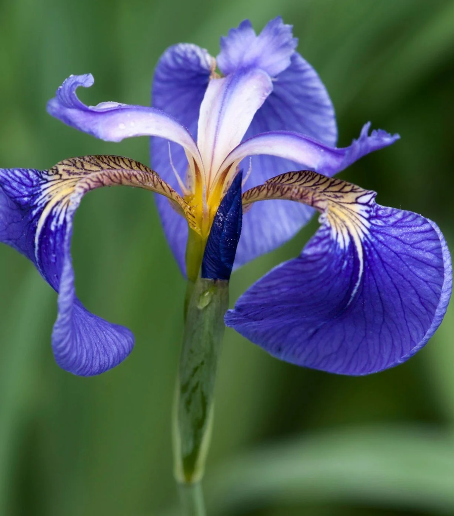

Notice that the two objects we created so far can be seen in the `Environment`.

## First step in R/Rstudio

### Data description

By clicking on the object in the `Environment` panel, you can visualize it, but you can also write some code to describe it. As we just checked, `data` is a `data.frame` object. It is made of several columns and rows.

To call a specific column in a dataframe, we use the `$` operator. To know all the column names in `data`, we can use the function `names()`. To know the “size” of the dataframe, the right function is `dim()`: the first element is the number of rows and the second the number of columns.

**Tip**

You can also call a column by its position in the dataframe. For instance, to call the second column you can type `data[,2]`. For the second row: `data[2,]`. What should you write to print the 10th element of the 3rd column?

To describe the data, we can use several built-in functions.

```r
table(data$Species) # To make a frequency table
```

```
    setosa versicolor  virginica
        50         50         50
```

```r
summary(data$Sepal.Length) # To provide summary statistics
```

```
   Min. 1st Qu.  Median    Mean 3rd Qu.    Max.
  4.300   5.100   5.800   5.843   6.400   7.900
```

## First step in R/Rstudio

### Our first graph!

Now, we want to visualize the data. To do so, we can use base R function `plot`:

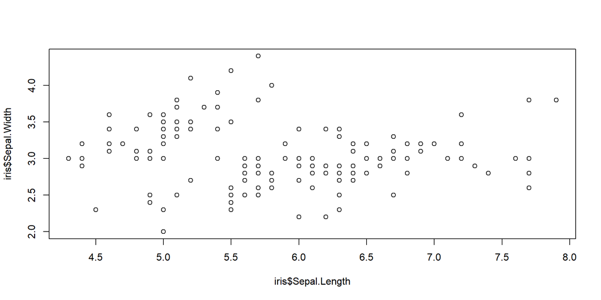

```r
plot(iris$Sepal.Length,iris$Sepal.Width)
```

We can also use a very popular library for data visualization, `ggplot2`. First, we install it, then we load it, to be able to use it.

```r
install.packages("ggplot2",repos = "http://cran.us.r-project.org")
library(ggplot2)
```

**Note**

A more efficient alternative is to use the `p_load` function of the `pacman` package. It installs only uninstalled packages and immediatly loads them: pacman::p_load(ggplot2)

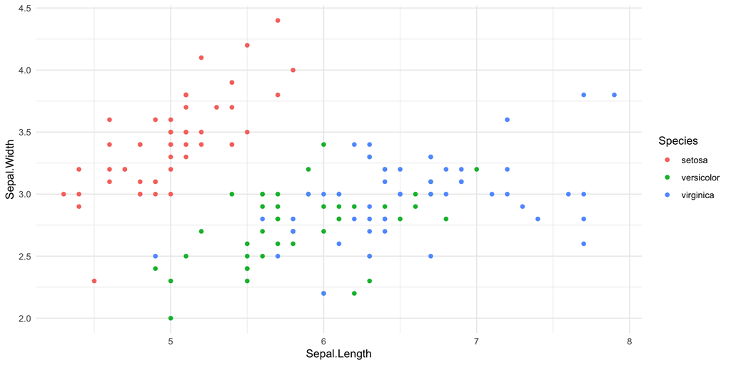

```r
g1 <- ggplot(data = data, mapping = aes(x = Sepal.Length, y = Sepal.Width, color = Species)) +
  geom_point() +
  theme_minimal()
g1
```

This looks better! To produce this graph we used different information:

- The `ggplot` command takes `data` and `mapping` as input.
  - `data` should be the dataset you want to visualize, here we named it `data`
  - `mapping` takes `aes` (for aesthetics): Here, the aesthetics are the `x` and `y` axis and `color`, to distinguish between the species.
  - `geom_point` allows to plot… points
  - `theme_minimal` makes the graph tidy, with a white background, etc.

**Tip**

R Packages come with documentation of their functions and syntax (sometimes even cheatsheets), typically [online](https://ggplot2.tidyverse.org/index.html). For a given function, you can also use the help() function within R.

Now, we want to save our graph:

```r
ggsave(filename = paste0(output_path,"/graph_iris.png"),plot = g1)
```

**Tip**

The function `paste0` is useful to concatenate text. Here, instead of writing the full path, we concatenate `output_path` and the end of the path, namely the desired file name.

## First step in R/Rstudio

### Data: base vs. dplyr

To finish this short introduction to R, let’s introduce a new package, one of the most popular in R: `dplyr`. As before, we install then load the library.

```r
pacman::p_load(tidyverse)
```

To be specific, the `tidyverse` is a collection of packages built for data science, including:

- `ggplot2` that we already installed separately
- `dplyr` that introduces a unified syntax for data manipulation
- 7 other main packages for data analysis (see the list [here](https://tidyverse.org/packages/))
- Other specific packages that are not directly loaded by `tidyverse`

Let’s imagine we want to filter the dataset to keep only the `setosa`. In base R, we need to extract the lines of `iris` for which `Species=="setosa"`. We store it into another object, here: `base_setosa`.

> The data frame `iris` is close to a matrix, hence, we can extract parts of it using notations close to the matrix ones. Hence `data[1,1]` would give us the first line of the first column (in this order) of `data`. Here, we filter the lines using a condition: `data$Species=="setosa"`. Do not forget the `,`.

```r
# Base R: Filter rows where Species is "setosa"
base_setosa <- data[data$Species == "setosa", ]
head(base_setosa)
```

```
  Sepal.Length Sepal.Width Petal.Length Petal.Width Species
1          5.1         3.5          1.4         0.2  setosa
2          4.9         3.0          1.4         0.2  setosa
3          4.7         3.2          1.3         0.2  setosa
4          4.6         3.1          1.5         0.2  setosa
5          5.0         3.6          1.4         0.2  setosa
6          5.4         3.9          1.7         0.4  setosa
```

`dplyr` introduces data manipulation functions, and the `pipe` operator `%>%`. We apply the function `filter` on variable `Species`.

```r
# dplyr: Filter rows where Species is "setosa"
dplyr_setosa <- as_tibble(iris) %>%
  filter(Species == "setosa")
head(dplyr_setosa)
```

```
# A tibble: 6 × 5
  Sepal.Length Sepal.Width Petal.Length Petal.Width Species
         <dbl>       <dbl>        <dbl>       <dbl> <fct>
1          5.1         3.5          1.4         0.2 setosa
2          4.9         3            1.4         0.2 setosa
3          4.7         3.2          1.3         0.2 setosa
4          4.6         3.1          1.5         0.2 setosa
5          5           3.6          1.4         0.2 setosa
6          5.4         3.9          1.7         0.4 setosa
```

Main `dplyr` functions are the following (check for their syntax [here](https://dplyr.tidyverse.org/)):

- `mutate()` adds new variables that are functions of existing variables
- `select()` selects variables based on their names
- `filter()` selects observations based on some conditions
- `summarise()` reduces multiple values down to a single summary
- `arrange()` changes the ordering of the rows

Next, we can select specific columns.

```r
# Base R: Select only Sepal.Length and Sepal.Width columns
base_columns <- iris[, c("Sepal.Length", "Sepal.Width")]
head(base_columns)
```

```
  Sepal.Length Sepal.Width
1          5.1         3.5
2          4.9         3.0
3          4.7         3.2
4          4.6         3.1
5          5.0         3.6
6          5.4         3.9
```

```r
# dplyr: Select only Sepal.Length and Sepal.Width columns
dplyr_columns <- as_tibble(iris) %>%
  select(Sepal.Length, Sepal.Width)
head(dplyr_columns)
```

```
# A tibble: 6 × 2
  Sepal.Length Sepal.Width
         <dbl>       <dbl>
1          5.1         3.5
2          4.9         3
3          4.7         3.2
4          4.6         3.1
5          5           3.6
6          5.4         3.9
```

**Tip**

Best practice in the tidyverse is to use `tibbles`: it is a type of data frame with a more “tidy” behavior. Notes that on top of each variable of a tibble, `head()` indicates variable [types](https://tibble.tidyverse.org/articles/types.html)

Or create new variables

```r
# Base R: Create a new column with Sepal.Area (Sepal.Length * Sepal.Width)
iris$Sepal.Area <- iris$Sepal.Length * iris$Sepal.Width
head(iris)
```

```
  Sepal.Length Sepal.Width Petal.Length Petal.Width Species Sepal.Area
1          5.1         3.5          1.4         0.2  setosa      17.85
2          4.9         3.0          1.4         0.2  setosa      14.70
3          4.7         3.2          1.3         0.2  setosa      15.04
4          4.6         3.1          1.5         0.2  setosa      14.26
5          5.0         3.6          1.4         0.2  setosa      18.00
6          5.4         3.9          1.7         0.4  setosa      21.06
```

```r
# dplyr: Create a new column with Sepal.Area (Sepal.Length * Sepal.Width)
dplyr_iris <- as_tibble(iris) %>%
  mutate(Sepal.Area = Sepal.Length * Sepal.Width)
head(dplyr_iris)
```

```
# A tibble: 6 × 6
  Sepal.Length Sepal.Width Petal.Length Petal.Width Species Sepal.Area
         <dbl>       <dbl>        <dbl>       <dbl> <fct>        <dbl>
1          5.1         3.5          1.4         0.2 setosa        17.8
2          4.9         3            1.4         0.2 setosa        14.7
3          4.7         3.2          1.3         0.2 setosa        15.0
4          4.6         3.1          1.5         0.2 setosa        14.3
5          5           3.6          1.4         0.2 setosa        18
6          5.4         3.9          1.7         0.4 setosa        21.1
```

`dplyr` allows to combine such data manipulations in a clear and efficient way:

```r
dplyr_grouped <- as_tibble(iris) %>%
  mutate(Sepal.Area = Sepal.Length * Sepal.Width) %>%
  mutate(is.Sepal.Large = ifelse(Sepal.Area > median(Sepal.Area),1,0)) %>%
  group_by(Species) %>%
  summarize(mean_sepal_length = mean(Sepal.Length),
            count_sepal_large = sum(is.Sepal.Large))
print(dplyr_grouped)
```

```
# A tibble: 3 × 3
  Species    mean_sepal_length count_sepal_large
  <fct>                  <dbl>             <dbl>
1 setosa                  5.01                21
2 versicolor              5.94                18
3 virginica               6.59                36
```

Another package allows for even clearer and more efficient computations: [data_table](https://www.datacamp.com/cheat-sheet/the-datatable-r-package-cheat-sheet). Its basic logic is to enrich the base data frame operator `[` from `data[i,j]` into `data[i,j,by]`.

```r
pacman::p_load(data.table)
dt_grouped <- setDT(iris)[,`:=`(Sepal.Area = Sepal.Length * Sepal.Width,
                                is.Sepal.Large = ifelse(Sepal.Area > median(Sepal.Area),1,0))][,
                                  list(mean_sepal_length = mean(Sepal.Length),
                                       count_sepal_large = sum(is.Sepal.Large)),
                                  by = list(Species)]
print(dt_grouped)
```

```
      Species mean_sepal_length count_sepal_large
       <fctr>             <num>             <num>
1:     setosa             5.006                21
2: versicolor             5.936                18
3:  virginica             6.588                36
```

For involved computations, data table usually performs better and can yield a leaner code.

**Tip**

Most dplyr functions have their data table equivalent. My recommendation is to experiment with both, select one then stick to it.

Our results can be, of course represented visually:

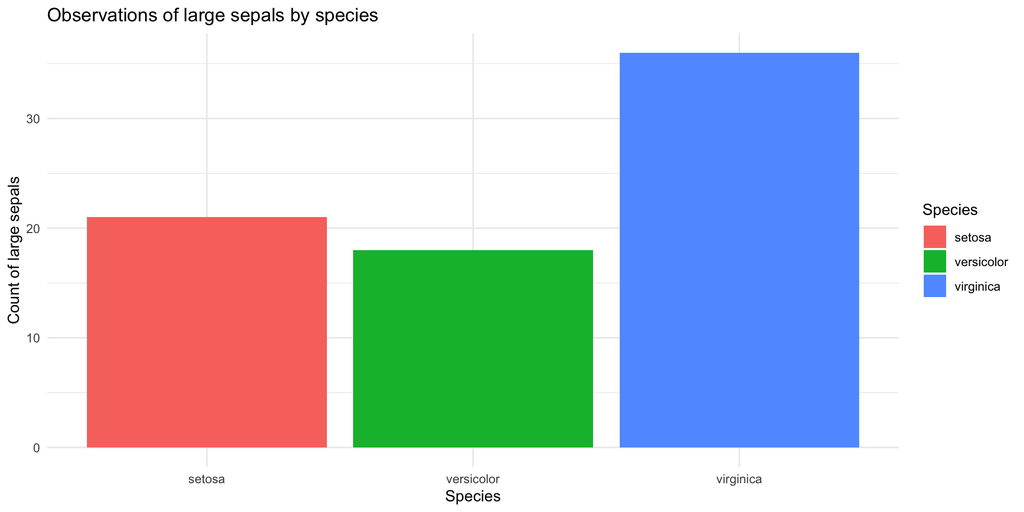

```r
ggplot(dplyr_grouped, aes(x = Species, y = count_sepal_large, fill = Species)) +
  geom_col() +
  labs(title = "Observations of large sepals by species",
       x = "Species", y = "Count of large sepals") +
  theme_minimal()
```

But we can also export it to `LaTeX`:

```r
pacman::p_load(xtable)
```

```r
colnames(dplyr_grouped) <- c("Species", "Mean_Sepal_Length", "Count_Sepal_Large")
print(xtable(dplyr_grouped), type = "latex", file = paste0(output_path,"/sepal_large.tex"))
```

## First step in LaTeX

### What is LaTeX

LaTeX is very popular software to produce scientic writings. It is relatively easy to use. In these tutorial lessons, it will be required of you to hand out your outputs using LaTeX. You have three options to use LaTeX:

1. Use any text editor and compile the file using the console
2. Use an IDE, like TexStudio or TexLive
3. Use an online IDE like Overleaf (allowing for collaboration)

**Tip**

There are plenty of tutorials to learn how to use LaTex, for example on [Overleaf](https://www.overleaf.com/learn/latex/Learn_LaTeX_in_30_minutes) Overleaf also delivers a bank of [open source templates](https://www.overleaf.com/latex/templates/tagged/academic-journal) for different kinds of document classes

## First step in LaTeX

### Overleaf

Open a blank project in Overleaf. It should look like that:

```
\documentclass{article}

%% PREAMBULE ------------------

\usepackage{graphicx} % Required for inserting images

%% METADATA -------------------

\title{Tutorial one}
\author{Aurel Mélard}
\date{February 2026}

%% DOCUMENT START ------------

\begin{document}

\maketitle

\section{Introduction}

\end{document}
```

Three elements are mandatory here: the `\documentclass{}` call, the `\begin{document}` and the `\end{document}` parts. The preambule is of high importance: it allows you to load packages to perform specific tasks. Here, `graphicx` is useful to input images. Other popular packages include:

- `geometry` allows you to change the margins of the pages,
- `booktab` to build nice-looking tables
- `tikz` to draw graphs directly in LaTeX
- `xcolor` to create and choose your favorite colors

You can then directly write any text you like after `\begin{document}`.

## First step in LaTeX

### Math mode

You can write equations in Latex using the math mode, in line using `$x = y$`:

```
My first equation is $  \mu_k = \int_0^{+\infty} x^k f(x) dx = \int_0^{+\infty} t^{-\frac{k}{\alpha}} \exp ^{-t} dt $
```

As line separate from text using `$$x = y$$`:

```
 $$\mu_k = \int_0^{+\infty} x^k f(x) dx = \int_0^{+\infty} t^{-\frac{k}{\alpha}} \exp ^{-t} dt $$
```

Or in equation mode:

```
\begin{equation}
  \mu_k = \int_0^{+\infty} x^k f(x) dx = \int_0^{+\infty} t^{-\frac{k}{\alpha}} \exp ^{-t} dt
\end{equation}
```

**Tip**

An environment starts with `\begin{name}` and ends with `\end{name}`. The environment can be an equation, a figure, a table, etc. An advantage of the equation environment over the `$$` operator is that you can name it, give it a number and refer to it

## First step in LaTeX

### Include our results (fig)

```
\begin{figure}
  \centering
  \includegraphics[width=0.8\linewidth]{graph/graph_iris.png}
  \caption{Iris sepals length and width}
\end{figure}
```

We work within the `figure` environment, center the graphic, include it with some options and add a caption. The graph should be uploaded in the project first! Here, I stored it in the folder `graph`.

## First step in LaTeX

### Include our results (table)

To input the table, we can use `\input{}`:

```
\input{table/sepal_large.tex}
```

No need to specify the environment as it was directly created by the `xtable` function earlier on!

## First step in LaTeX

### Compile the file

> LaTeX is not a “What You See Is What You Get” software, like Word or Canvas.
- You need to compile the code to obtain the results (usually a `.pdf`), that you can further download.

## Quick exercise

1. Open a new script, add the relevant information (path, date, packages) and load the `swiss` dataset
2. Create a grouping variable if `Catholic` is below median or under median
3. Using the `dplyr` syntax, compute the number of observations, the mean, median, and inter-quartile range of `Fertility`, `Agriculture`, and `Education` by group. Save as a `.tex` table.
4. Plot the relation between `Education` and `Infant.Mortality` (`ggplot2` syntax) for each group
   1. With a scatter plot and lines that connects all points
   2. Add a title and a subtitle (centered and in bold)
   3. Put the legend at the bottom of the slide
   4. Export as a `.pdf`
5. Export everything in a TeX file